# Spam Email Classification

The topic of this project is to experiment with different models to find which one works best for Email Classification. This is a **binary classification** problem that will be solved using supervised learning.

The dataset was obtained from [UCI](https://archive.ics.uci.edu/dataset/94/spambase):  
Hopkins, M., Reeber, E., Forman, G., & Suermondt, J. (1999). Spambase [Dataset]. UCI Machine Learning Repository. https://doi.org/10.24432/C53G6X.

A similar problem was tackled in module 4, though it was solved using regulated decision trees only. This project aims to tackle it using Logistic Regression, Ensembles and SVMs, and conclude which parameters give the best results.

The data structure is basically the same as the `spamdata.csv` used in module 4. To quote UCI's description on the source of the data and why it was structured the way it is:

> Our collection of spam e-mails came from our postmaster and individuals who had filed spam. Our collection of non-spam e-mails came from filed work and personal e-mails, and hence the word 'george' and the area code '650' are indicators of non-spam. These are useful when constructing a personalized spam filter. One would either have to blind such non-spam indicators or get a very wide collection of non-spam to generate a general purpose spam filter.

The data contains 4601 data points with 57 features in total. The following description of the features was also adapted from UCI's website:

> 48 continuous real [0,100] attributes of type word_freq_WORD  
> = percentage of words in the e-mail that match WORD, i.e. 100 * (number of times the WORD appears in the e-mail) / total number of words in e-mail. A "word" in this case is any string of alphanumeric characters bounded by non-alphanumeric characters or end-of-string.  
> 6 continuous real [0,100] attributes of type char_freq_CHAR]  
> = percentage of characters in the e-mail that match CHAR, i.e. 100 * (number of CHAR occurences) / total characters in e-mail  
> 1 continuous real [1,...] attribute of type capital_run_length_average  
> = average length of uninterrupted sequences of capital letters  
> 1 continuous integer [1,...] attribute of type capital_run_length_longest  
> = length of longest uninterrupted sequence of capital letters  
> 1 continuous integer [1,...] attribute of type capital_run_length_total  
> = sum of length of uninterrupted sequences of capital letters  
> = total number of capital letters in the e-mail  
> 1 nominal {0,1} class attribute of type spam  
> = denotes whether the e-mail was considered spam (1) or not (0), i.e. unsolicited commercial e-mail.

## Cleaning

The data does not need cleaning as it comes already clean.

## Can we do better?

One of the objectives will be to obtain results better than those shown on the UCI website. The website gives the following achieved precisions:

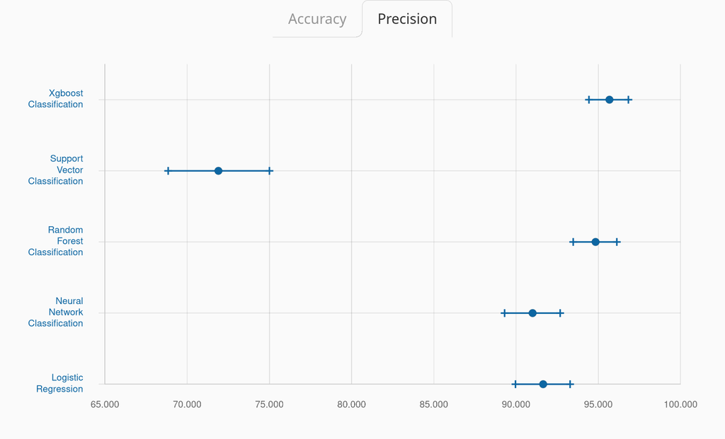

As well as the following accuracy data:

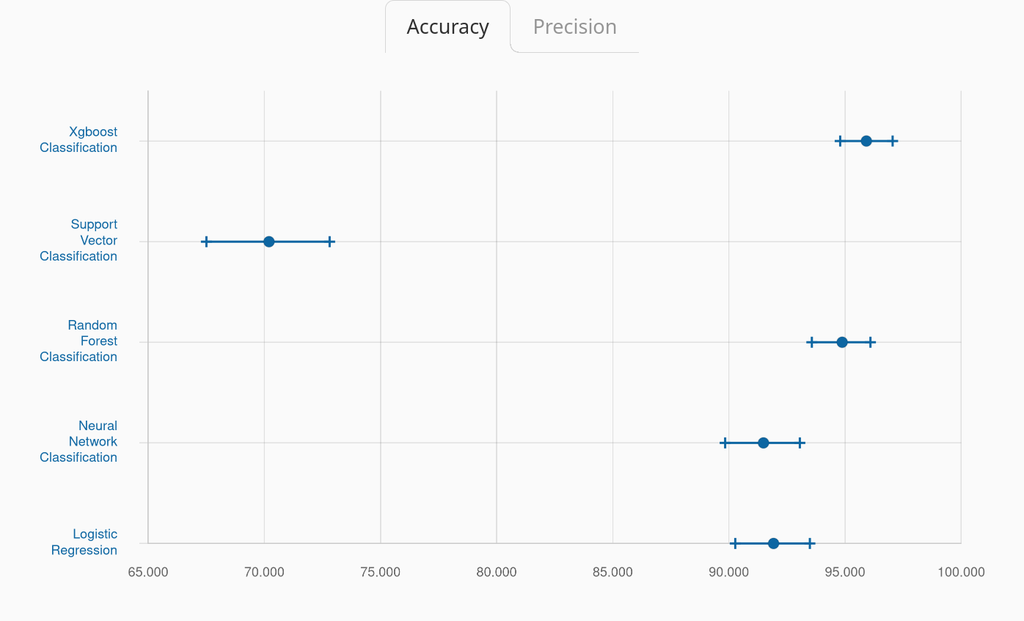

## Preparations

### Importing packages

The cell below ensures required packages are imported.

```python
import math
import numpy as np
import matplotlib.pylab as plt
%matplotlib inline

# importing all the required libraries

from math import exp
import numpy as np
import pandas as pd
import seaborn as sns
import sklearn
from sklearn.linear_model import LogisticRegression
from sklearn.tree import DecisionTreeClassifier
from sklearn.ensemble import RandomForestClassifier, AdaBoostClassifier
from sklearn.svm import SVC, LinearSVC
from sklearn.model_selection import train_test_split, cross_val_score, GridSearchCV
from matplotlib.colors import Normalize
import matplotlib.pyplot as plt
%matplotlib inline

from sklearn.metrics import roc_auc_score
from sklearn.metrics import roc_curve
```

### Import the data

The following cells import the data and split it appropriately.

```python
!pip install ucimlrepo
```

```python
from ucimlrepo import fetch_ucirepo

# fetch dataset
spambase = fetch_ucirepo(id=94)

# data (as pandas dataframes)
X = spambase.data.features
y = spambase.data.targets

# variable information
print(spambase.variables)

# metadata
spambase.metadata
```

```
                          name     role        type demographic  \
0               word_freq_make  Feature  Continuous        None
1            word_freq_address  Feature  Continuous        None
2                word_freq_all  Feature  Continuous        None
3                 word_freq_3d  Feature  Continuous        None
4                word_freq_our  Feature  Continuous        None
5               word_freq_over  Feature  Continuous        None
6             word_freq_remove  Feature  Continuous        None
7           word_freq_internet  Feature  Continuous        None
8              word_freq_order  Feature  Continuous        None
9               word_freq_mail  Feature  Continuous        None
10           word_freq_receive  Feature  Continuous        None
11              word_freq_will  Feature  Continuous        None
12            word_freq_people  Feature  Continuous        None
13            word_freq_report  Feature  Continuous        None
```

[output cut: 104 more lines]

[output not shown]

```python
X_train, X_test, y_train, y_test = train_test_split(X, y, random_state=10, test_size=.1)
```

### Helpful functions

```python
# Adapted from Module 6, used by plotSearchGrid
class MidpointNormalize(Normalize):

    def __init__(self, vmin=None, vmax=None, midpoint=None, clip=False):
        self.midpoint = midpoint
        Normalize.__init__(self, vmin, vmax, clip)

    def __call__(self, value, clip=None):
        x, y = [self.vmin, self.midpoint, self.vmax], [0, 0.5, 1]
        return np.ma.masked_array(np.interp(value, x, y))

# Adapted from Module 6
def plotSearchGrid(grid, var1, var2):
    scores = [x for x in grid.cv_results_["mean_test_score"]]
    scores = np.array(scores).reshape(len(grid.param_grid[var1]), len(grid.param_grid[var2]))
    #plt.figure(figsize=(10, 8))
    plt.subplots_adjust(left=.2, right=0.95, bottom=0.15, top=0.95)
    plt.imshow(scores, interpolation='nearest', cmap=plt.cm.hot,
               norm=MidpointNormalize(vmin=0.2, midpoint=0.92))
    plt.xlabel(var2)
    plt.ylabel(var1)
    plt.colorbar()
    plt.xticks(np.arange(len(grid.param_grid[var2])), grid.param_grid[var2], rotation=45)
    plt.yticks(np.arange(len(grid.param_grid[var1])), grid.param_grid[var1])
    plt.title('Validation accuracy')
    plt.show()

def calculate_precision(y_true, y_pred, pos_label_value=1.0):
    '''
    This function accepts the labels and the predictions, then
    calculates precision for a binary classifier.

    Args
        y_true: np.ndarray
        y_pred: np.ndarray

        pos_label_value: (float) the number which represents the postiive
        label in the y_true and y_pred arrays. Other numbers will be taken
        to be the non-positive class for the binary classifier.

    Returns precision as a floating point number between 0.0 and 1.0
    '''
    TP = np.sum((y_true == pos_label_value) * (y_pred == pos_label_value))
    P_data = np.sum(y_pred == pos_label_value)
    return TP/P_data

def calculate_recall(y_true, y_pred, pos_label_value=1.0):
    '''
    This function accepts the labels and the predictions, then
    calculates recall for a binary classifier.

    Args
        y_true: np.ndarray
        y_pred: np.ndarray

        pos_label_value: (float) the number which represents the postiive
        label in the y_true and y_pred arrays. Other numbers will be taken
        to be the non-positive class for the binary classifier.

    Returns precision as a floating point number between 0.0 and 1.0
    '''
    TP = np.sum((y_true == pos_label_value) * (y_pred == pos_label_value))
    P_data = np.sum(y_true == pos_label_value)
    return TP/P_data
```

## EDA

All the data, exept the results, are continuous numbers. As there are way too many features to do a figure/analyses for each, the EDA will focus on the correlation between the features, starting with a correlation heatmap.

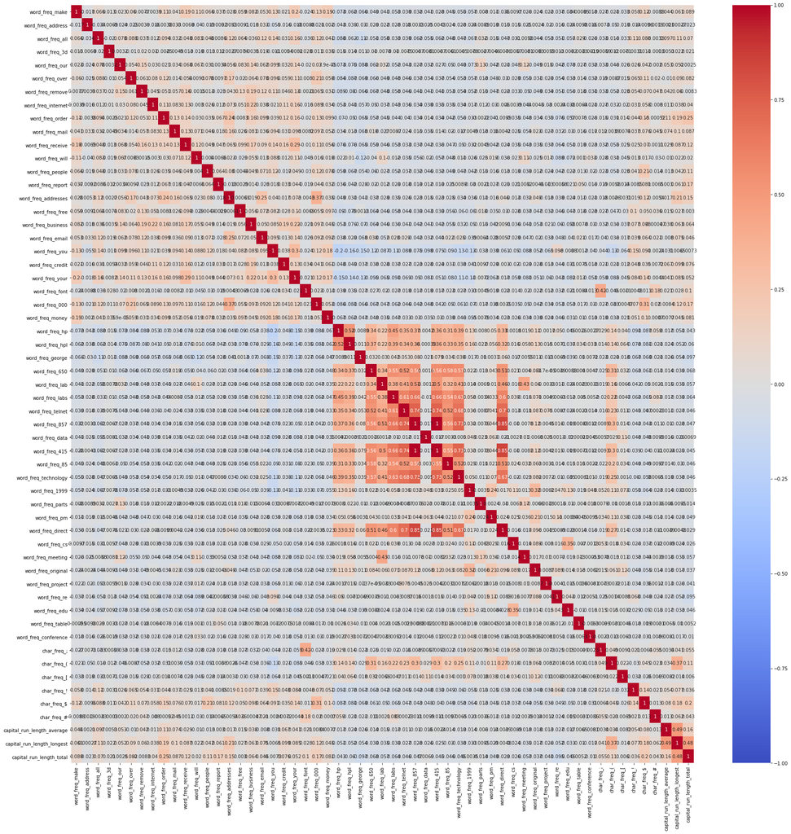

```python
sns.heatmap(X.corr(), -1, 1, "coolwarm", 0, annot=True, ax=plt.subplots(figsize=(30,30))[1])
```

From the correlation heat map above, we see that there are two "groups" of high correlation - one between 11 particular word frequecies, and one between the capital run lengths. In particular, word_freq_857 and word_freq_415 have a collinearity of 1, meaning that at least one of them is practically redundant.

The two groups are further explored using pairplots below.

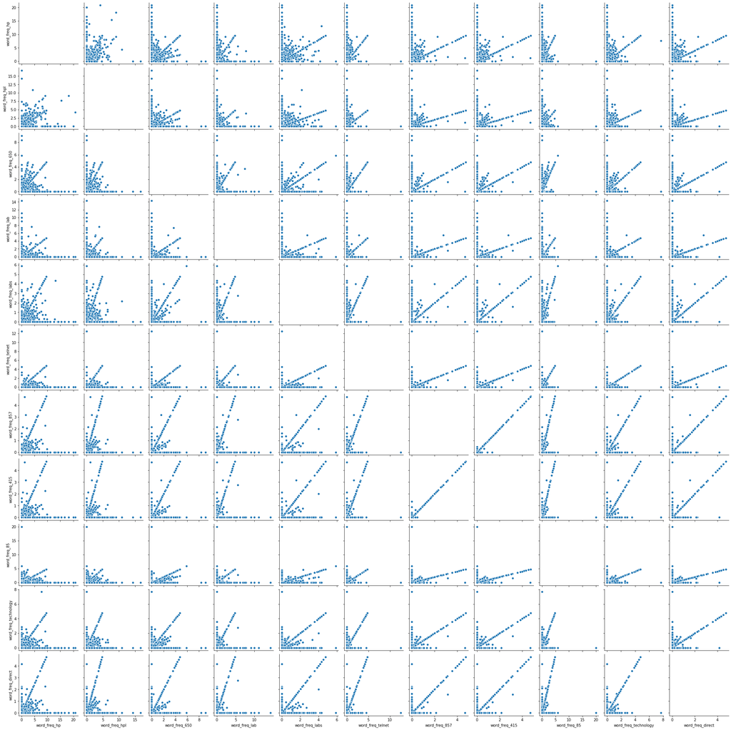

```python
sns.pairplot(X[["word_freq_hp", "word_freq_hpl", "word_freq_650", "word_freq_lab", "word_freq_labs", "word_freq_telnet", "word_freq_857", "word_freq_415", "word_freq_85", "word_freq_technology", "word_freq_direct"]], diag_kind="kde")
```

As we see above. The patterns show a very high degree of collinearity. With that we expect that the regulation coefficient will have a big impact on improving the Logistic Regression model.

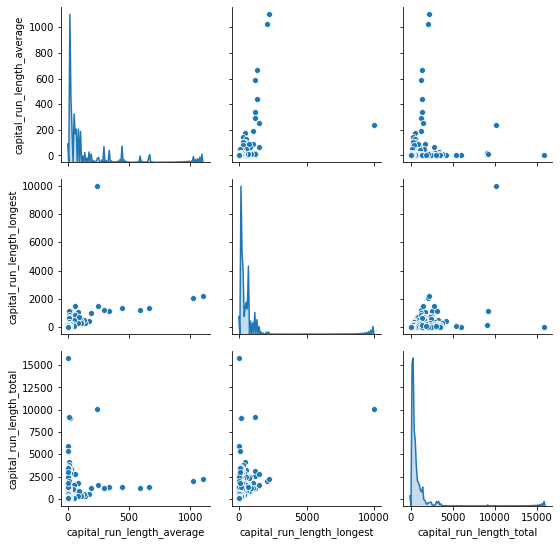

```python
sns.pairplot(X[["capital_run_length_average", "capital_run_length_longest", "capital_run_length_total"]], diag_kind="kde")
```

As for the capital run lengths, they are obviously collinear, though less obvious from the plots. As we will see from the Logistic Regression coefficients, capital_run_length_total gets almost rid off by the regulation, while word_freq_857 is becomes literally 0.

## Model training

### Logistic Regression

The first model to use is logistic regression. Using GridSearchCV, different regulation techniques and strengths can be experimented with.

Logistic Regression ordinarily suffers from the curse of dimensionality. However with regulation, especially l1, this becomes less of a concern.

The coefficients from the best model are printed to provide some insight onto which features had the most influence.

```python
LogRegGrid = GridSearchCV(
    LogisticRegression(solver="liblinear"),
    {
        "penalty": ("l1", "l2"),
        "C": np.logspace(-5, 5, base=2, num=11)
    }
).fit(X_train, y_train)
```

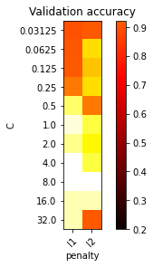

```
Best Logistic Regression parameters: {'C': 8.0, 'penalty': 'l1'}
Best Logistic Regression score: 0.9231884057971016
```

```python
plotSearchGrid(LogRegGrid, "C", "penalty")
print("Best Logistic Regression parameters:", LogRegGrid.best_params_)
print("Best Logistic Regression score:", LogRegGrid.best_score_)
LogRegBest = LogRegGrid.best_estimator_
```

```python
for feature, coef in zip(X.columns.tolist(), LogRegBest.coef_[0]):
    print(feature, ":", coef)
```

```
word_freq_make : -0.3352771610625865
word_freq_address : -0.144134104466229
word_freq_all : 0.112018672406649
word_freq_3d : 2.076387357353494
word_freq_our : 0.554593550485832
word_freq_over : 1.2904401963364194
word_freq_remove : 2.5267285725399806
word_freq_internet : 0.5172196645160981
word_freq_order : 0.627473532037221
word_freq_mail : 0.17249868699823487
word_freq_receive : -0.25581126978924495
word_freq_will : -0.14234046357326724
word_freq_people : -0.11854115705721327
word_freq_report : 0.17412149671014215
word_freq_addresses : 1.0500388675253347
word_freq_free : 0.9634466906627731
word_freq_business : 0.9305392973545669
word_freq_email : 0.10133392987631257
word_freq_you : 0.08488243536713497
word_freq_credit : 1.3819517056872157
word_freq_your : 0.2654681374949797
word_freq_font : 0.21749820028292105
word_freq_000 : 2.0810250283128378
word_freq_money : 0.36561247488532317
word_freq_hp : -1.7902775548167147
word_freq_hpl : -1.2336732801585475
word_freq_george : -10.880824805770052
word_freq_650 : 0.44226034330510694
word_freq_lab : -2.2885745842672742
word_freq_labs : -0.2654647593774336
word_freq_telnet : -0.16163430120735922
word_freq_857 : 0.0
word_freq_data : -0.785684361230612
word_freq_415 : 0.45936893654380306
word_freq_85 : -1.9259154363336377
word_freq_technology : 0.8586013549791187
word_freq_1999 : 0.09105557504327932
word_freq_parts : -0.5351601870000458
word_freq_pm : -0.7897860751763727
word_freq_direct : -0.3114823079515479
word_freq_cs : -16.272347427710518
word_freq_meeting : -2.513144116975214
word_freq_original : -1.1180888218223113
word_freq_project : -1.6215101779132928
word_freq_re : -0.8091323320430137
word_freq_edu : -1.307624281598115
word_freq_table : -1.3921522502944936
word_freq_conference : -3.6846542873407873
char_freq_; : -1.233208442411895
char_freq_( : -0.13236694620475534
char_freq_[ : -0.545299178734433
char_freq_! : 0.3144554745969651
char_freq_$ : 4.90464860192831
char_freq_# : 1.85535122747682
capital_run_length_average : 0.014264456456158873
capital_run_length_longest : 0.007832612484971016
capital_run_length_total : 0.0008400454072136723
```

#### Feature ranking

It seems from the data above that the $ sign is the strongest spam indicator, while cs is the strongest anti-indicator.

The data used was not normalized though, so one should exercise caution when ranking solely based on the feature coefficients.

### Decision Tree Ensembles

Second ensembles are used. Both Random Forest and AdaBoost are used.

The best n_estimators for both is searched for. In addition, Random Forest experiments with max_depth, while AdaBoost experiments with learning_rate.

In module 4 using Decision Trees, we could not get an accuracy above 0.95 for the test data. Can we do better?

```python
RFGrid = GridSearchCV(
    RandomForestClassifier(max_samples=.7),
    {
        "max_depth": range(10, 20, 3),
        "n_estimators": range(100, 1100, 300)
    }
).fit(X_train, y_train)
```

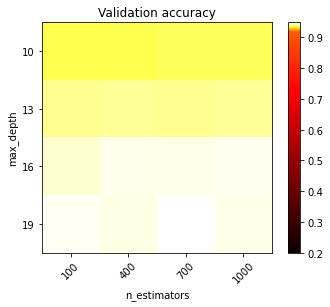

```
Best Random Forest parameters: {'max_depth': 19, 'n_estimators': 700}
Best Random Forest score: 0.9487922705314009
```

```python
plotSearchGrid(RFGrid, "max_depth", "n_estimators")
print("Best Random Forest parameters:", RFGrid.best_params_)
print("Best Random Forest score:", RFGrid.best_score_)
RFBest = RFGrid.best_estimator_
```

```python
ABGrid = GridSearchCV(
    AdaBoostClassifier(),
    {
        "learning_rate": np.logspace(-4, -1, base=2, num=4),
        "n_estimators": range(100, 1100, 300)
    }
).fit(X_train, y_train)
```

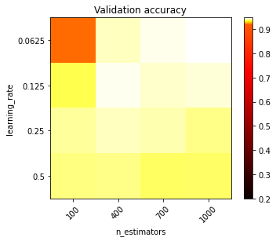

```
Best AdaBoost parameters: {'learning_rate': 0.0625, 'n_estimators': 1000}
Best AdaBoost score: 0.9475845410628019
```

```python
plotSearchGrid(ABGrid, "learning_rate", "n_estimators")
print("Best AdaBoost parameters:", ABGrid.best_params_)
print("Best AdaBoost score:", ABGrid.best_score_)
ABBest = ABGrid.best_estimator_
```

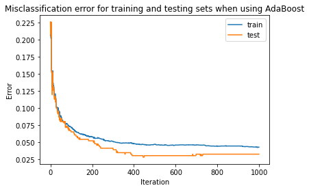

```python
fig, ax = plt.subplots()
ax.set_xlabel("Iteration")
ax.set_ylabel("Error")
ax.set_title("Misclassification error for training and testing sets when using AdaBoost")
ax.plot(1 - np.fromiter(ABBest.staged_score(X_train, y_train), float), label="train")
ax.plot(1 - np.fromiter(ABBest.staged_score(X_test, y_test), float), label="test")
ax.legend()
plt.show()
```

## SVMs

Finally SVMs are used, first with rbf kernels as they seem to strike a good balance in my opinion and require optimisation. GridSearchCV is employed to find the best values for C and gamma.

Then we check if the simpler LinearSVC actually performs better or not on this dataset.

SVMs could be a great model for this dataset as it is less vulnerable to the curse of dimensionality, but will the assumption of the existence of a separating hyperplace apply well to this situation?

```python
SVCGrid = GridSearchCV(
    SVC(),
    {
        "gamma": np.logspace(-7, -3, base=2, num=5),
        "C": np.logspace(1, 5, base=2, num=5)
    }
).fit(X_train, y_train)
```

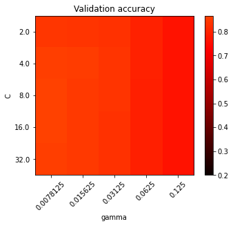

```
Best SVM parameters: {'C': 8.0, 'gamma': 0.0078125}
Best SVM score: 0.8657004830917874
```

```python
plotSearchGrid(SVCGrid, "C", "gamma")
print("Best SVM parameters:", SVCGrid.best_params_)
print("Best SVM score:", SVCGrid.best_score_)
SVCBest = SVCGrid.best_estimator_
```

```python
SVCGrid2 = GridSearchCV(
    LinearSVC(),
    {
        "loss": ("hinge", "squared_hinge"),
        "C": np.logspace(-15, -5, base=2, num=11)
    }
).fit(X_train, y_train)
```

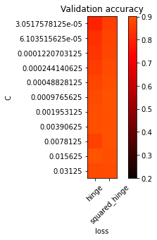

```
Best LinearSVC parameters: {'C': 0.015625, 'loss': 'hinge'}
Best LinearSVC score: 0.9031400966183576
```

```python
plotSearchGrid(SVCGrid2, "C", "loss")
print("Best LinearSVC parameters:", SVCGrid2.best_params_)
print("Best LinearSVC score:", SVCGrid2.best_score_)
LinearSVCBest = SVCGrid2.best_estimator_
```

## Results

We start by checking the validation scores (using the initial train-test split, not CV) of each of the best models:

```python
print("Logistic Regression validation score:", LogRegBest.score(X_test, y_test))
print("Random Forest       validation score:", RFBest.score(X_test, y_test))
print("AdaBoost            validation score:", ABBest.score(X_test, y_test))
print("SVM with rbf        validation score:", SVCBest.score(X_test, y_test))
print("Linear SVC          validation score:", LinearSVCBest.score(X_test, y_test))
```

```
Logistic Regression validation score: 0.9501084598698482
Random Forest       validation score: 0.9631236442516269
AdaBoost            validation score: 0.9674620390455532
SVM with rbf        validation score: 0.8937093275488069
Linear SVC          validation score: 0.9175704989154013
```

Comparing these values, all models outperform the baseline model scores published on UCI's website, and by a good margin.

But do we get better precision values as well? Let's check:

```python
# These variables store the true and predicted values so we don't need to recalculate them again and again.
y_test_flat = np.ravel(y_test)
LogRegPredict = LogRegBest.predict(X_test)
RFPredict = RFBest.predict(X_test)
ABPredict = ABBest.predict(X_test)
SVCPredict = SVCBest.predict(X_test)
LinearSVCPredict = LinearSVCBest.predict(X_test)
```

```python
print("Logistic Regression precision score:", calculate_precision(y_test_flat, LogRegPredict))
print("Random Forest       precision score:", calculate_precision(y_test_flat, RFPredict))
print("AdaBoost            precision score:", calculate_precision(y_test_flat, ABPredict))
print("SVM with rbf        precision score:", calculate_precision(y_test_flat, SVCPredict))
print("Linear SVC          precision score:", calculate_precision(y_test_flat, LinearSVCPredict))
```

```
Logistic Regression precision score: 0.9481865284974094
Random Forest       precision score: 0.9735449735449735
AdaBoost            precision score: 0.9738219895287958
SVM with rbf        precision score: 0.8808290155440415
Linear SVC          precision score: 0.9247311827956989
```

The precision values also outperform the baseline model scores.

While recall values are not given by the UCI website, let us calculate them nonetheless:

```python
print("Logistic Regression recall score:", calculate_recall(y_test_flat, LogRegPredict))
print("Random Forest       recall score:", calculate_recall(y_test_flat, RFPredict))
print("AdaBoost            recall score:", calculate_recall(y_test_flat, ABPredict))
print("SVM with rbf        recall score:", calculate_recall(y_test_flat, SVCPredict))
print("Linear SVC          recall score:", calculate_recall(y_test_flat, LinearSVCPredict))
```

```
Logistic Regression recall score: 0.9336734693877551
Random Forest       recall score: 0.9387755102040817
AdaBoost            recall score: 0.9489795918367347
SVM with rbf        recall score: 0.8673469387755102
Linear SVC          recall score: 0.8775510204081632
```

Finally, let us check the ROC curves:

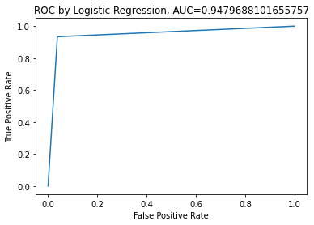

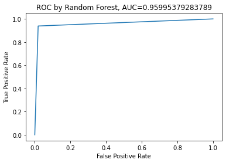

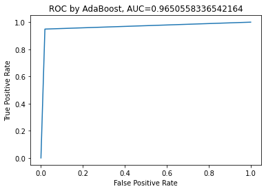

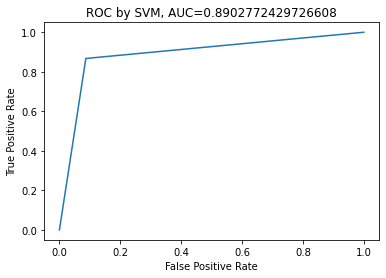

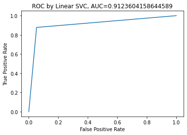

```python
for label, pred in ("Logistic Regression", LogRegPredict), ("Random Forest", RFPredict), ("AdaBoost", ABPredict), ("SVM", SVCPredict), ("Linear SVC", LinearSVCPredict):
    fpr, tpr, _ = roc_curve(y_test_flat, pred)
    roc_auc = roc_auc_score(y_test_flat, pred)
    plt.plot(fpr, tpr, label=f"micro-average ROC curve (AUC = {roc_auc})")
    plt.title(f"ROC by {label}, AUC={roc_auc}")
    plt.xlabel("False Positive Rate")
    plt.ylabel("True Positive Rate")
    plt.show()
```

## Analysis, Discussion and Conclusion

Comparing the above results, we can safely say that the ensemble models (Random Forest and AdaBoost) outdid the other models by far. Logistic Regression did not do bad either.

SVMs though performed quite poorly. It seems that the assumptions inherit to SVMs do not hold well for the dataset at hand. This might have been expected though, given that the SVC baseline model from UCI did poorly as well. The fact that LinearSVC performed better than rbf was more surprising though. It seems that the underlaying model is more linear than circular, as evidenced by the rbf model leaning strongly towards smaller gamma values.

It seems that the model preferred l1 regulisation. This was expected as this dataset contains high covariance requiring the effective elimination of some features. Though, looking at the heatmap, it seems that as regulation gets tight, l2 becomes more suitable.

One of the things that might improve the results is normalizing the data before training. That should help the regulisation be more fair between the features.

### Ensembles

Random Forest seemed to prefer deeper trees with this dataset, while AdaBoost performed better and better the lower the learning rate. From the Misclassification error graph obtained from the staged score, we can clearly see that AdaBoost does run the risk of slightly overfitting as the number of estimators increases.

Further experiments could attempt to improve on the results by trying deeper trees for Random Forest and even lower learning rates for AdaBoost.

### SVMs

As mentioned earlier, the rbf kernel performed poorly on the dataset, with it clearning leanning towards zero gamma. This might suggest that the non-linearity introduced by the kernel is instead causing overfitting.

Never the less, there might be some steps that can be taken to improve the results, such as normalizing the data beforehand.

### Precision vs Recall

In this particular case, false positives are especially bad - we never want legitimate email to be falsely classified as spam. False negatives on the other hand are less problematic. As such, precision is much more important than mere accuracy. Thankfully, from comparing the precisions to recalls, we see that precision is generally higher. Especially the ensembles are exceptional in terms of precision.

This result can be also seen from the ROC/AUC graphs. Both ensembles outperform the rest of the models.

That being said, this is still not satisfactory. Steps should be taken to increase the precision even if that meant lower accuracy overall. Possible methods include changing the accepting threshold for Logistic Regression or the corresponding weights for the other methods.

### Takeaway

Overall, it seems that Adaboost and Random Forest are the best algorithms for this task, as they top both precision and accuracy metrics. Improvements can be made though, both to incease the performance by tweeking the hyperparameters and insure that precision is given top priority.